# Term Project of BDA 507

dataMunglers

05 Jan 2018

### Team Members

- **[Ahmet Yetkin Eser](https://www.linkedin.com/in/ahmet-yetkin-eser-04178a40/)**
- **[Berkay Soyer](https://www.linkedin.com/in/berkaysoyer/)**
- **Feray Ece Topcu**

### Our Objective

Our aim is focusing on Turkey data,compared to distribution of world population. The main objective is understanding Turkey population distribution based on the different parameters like age, sex, year and etc. Exploring some information about population growing rate according to gender may be additional part. Furthermore, we want to visualize this numbers with graphs to make this dataset more understandable. To sum up, the main aim is understanding the distribution of Turkey and world population and exploring some interesting information by using PostgreSQL and R Language.

### Dataset

The United States Census Bureau???s International Dataset provides estimates of country populations since 1950 and projections through 2050. Specifically, the data set includes midyear population figures broken down by age and gender assignment at birth. Additionally, they provide time-series data for attributes including fertility rates, birth rates, death rates, and migration rates. The U.S. Census Bureau provides estimates and projections for countries and areas that are recognized by the U.S. Department of State that have a population of at least 5,000.

This dataset can be available from this URL: https://www.kaggle.com/census/international-data/data

Size of total dataset is 1.70 GB. It is formed by 8 different csv file that can be ordered as:

- age_specific_fertility_rates.csv
- birth_death_growth_rates.csv
- country_names_area.csv
- midyear_population.csv
- midyear_population_5yr_age_sex.csv
- midyear_population_age_country_code.csv
- midyear_population_age_sex.csv
- mortality_life_expectancy.csv

Tables are explained on Proposal Part briefly and proposal document can be reachable from [here](https://github.com/MEF-BDA503/pj-ferayece/blob/master/BDA-507/BDA%20505-Porposal.pdf)

## 1. Database Connection

- Load required libraries and show table names on the database.

```r
#load libraries:

library(dplyr)
library(tidyr)
library(stringr)
library(ggplot2)
library(corrplot)
library(RPostgreSQL)
library(gridExtra)
library(knitr)

#db connection with postgresql:

drvv <- dbDriver("PostgreSQL") # load postgresql driver

### create a connection to a database using the driver:
# con <- dbConnect(drvv,
#                  dbname = "InternationalDatasets",
#                  host = "localhost",
#                  port = 5432,
#                  user = "postgres",
#                  password = ".aabbcc."
#                  )

con <- dbConnect(drvv,
                 dbname = "postgres",
                 host = "localhost",
                 port = 5432,
                 user = "postgres",
                 password = "sys")

#dbDisconnect(con)   close the connection

#Read table names from DB:
table_names <- dbGetQuery(con,
                          "SELECT table_name
                          FROM information_schema.tables
                          WHERE table_type = 'BASE TABLE'
                          AND table_schema = 'public'
                          ORDER BY table_name
                          "
)

#table.Country <- dbReadTable(con, "country_names_area")

table_names %>%
  kable()
```

| table_name |
| --- |
| age_specific_fertility_rates |
| birth_death_growth_rates |
| country_names_area |
| midyear_population |
| midyear_population_5yr_age_sex |
| midyear_population_age_country_code |
| midyear_population_age_sex |
| mortality_life_expectancy |
| population_age_summary |

## 2. Explore the Data

### 2.1. Life Expectancy

- Take Life Expectancy Rate from PostGreSQL DB with the query as follow:

```r
query.lifeexpectancy<-dbGetQuery(con,"SELECT
                                      TR.YEAR,
                                      TR.LIFE_EXPECTANCY_MALE AS LIFE_EXPECTANCY_MALE_TR,
                                      TR.LIFE_EXPECTANCY_FEMALE AS LIFE_EXPECTANCY_FEMALE_TR,
                                      ROUND(CAST((TR.LIFE_EXPECTANCY_MALE/TR.LIFE_EXPECTANCY_FEMALE) AS NUMERIC), 2) AS MALE_FEMALE_RATIO_TR,
                                      TOT.LIFE_EXPECTANCY_MALE AS LIFE_EXPECTANCY_MALE_TOTAL,
                                      TOT.LIFE_EXPECTANCY_FEMALE AS LIFE_EXPECTANCY_FEMALE_TOTAL,
                                      ROUND(CAST((TOT.LIFE_EXPECTANCY_MALE/TOT.LIFE_EXPECTANCY_FEMALE) AS NUMERIC), 2) AS MALE_FEMALE_RATIO_TOT
                                      FROM
                                      (
                                          SELECT
                                          COUNTRY_NAME,
                                          YEAR,
                                          LIFE_EXPECTANCY_MALE,
                                          LIFE_EXPECTANCY_FEMALE
                                          FROM
                                          MORTALITY_LIFE_EXPECTANCY
                                          WHERE COUNTRY_NAME = 'Turkey'
                                          AND YEAR <= 2017
                                      ) TR
                                      JOIN
                                      (
                                          SELECT YEAR,
                                          ROUND(CAST(FLOAT8 (AVG(LIFE_EXPECTANCY_MALE)) AS NUMERIC), 2) AS LIFE_EXPECTANCY_MALE,
                                          ROUND(CAST(FLOAT8 (AVG(LIFE_EXPECTANCY_FEMALE)) AS NUMERIC), 2) AS LIFE_EXPECTANCY_FEMALE
                                          FROM
                                          MORTALITY_LIFE_EXPECTANCY
                                          WHERE YEAR <= 2017
                                          GROUP BY YEAR
                                      ) TOT ON TR.YEAR = TOT.YEAR
                                      ORDER BY TR.YEAR"
                                  )

# take life expectancy according to genders in Turkey:

le.male.tr <- query.lifeexpectancy %>%
  select(year,life_expectancy=life_expectancy_male_tr,male_female_ratio_tr) %>%
  mutate(sex="male")

le.female.tr <- query.lifeexpectancy %>%
  select(year,life_expectancy=life_expectancy_female_tr,male_female_ratio_tr) %>%
  mutate(sex="female")

le.tr <- union_all(le.male.tr,le.female.tr)

# take life expectancy according to genders in Total:

le.male.tot <- query.lifeexpectancy %>%
  select(year,life_expectancy=life_expectancy_male_total,male_female_ratio_tot) %>%
  mutate(sex="male")

le.female.tot <- query.lifeexpectancy %>%
  select(year,life_expectancy=life_expectancy_female_total,male_female_ratio_tot) %>%
  mutate(sex="female")

le.tot <- union_all(le.male.tot,le.female.tot)

le.tr %>% select(year,life_expectancy) %>%
  head(5)%>%
  kable()
```

| year | life_expectancy |
| --- | --- |
| 1980 | 60.86 |
| 1981 | 61.24 |
| 1982 | 61.61 |
| 1983 | 61.97 |
| 1984 | 62.33 |

```r
le.tot %>% select(year,life_expectancy) %>%
  head(5)%>%
  kable()
```

| year | life_expectancy |
| --- | --- |
| 1980 | 51.83 |
| 1981 | 54.20 |
| 1982 | 55.79 |
| 1983 | 56.33 |
| 1984 | 57.05 |

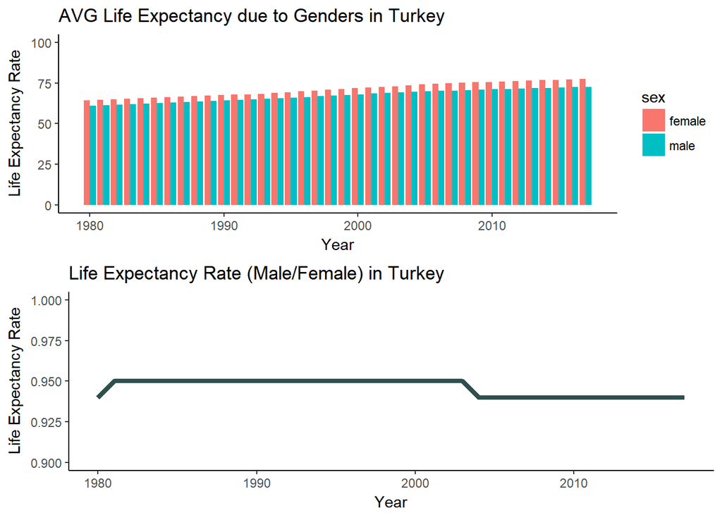

```r
#dim(query.lifeexpectancy)
#summary(query.lifeexpectancy)
#head(query.lifeexpectancy,5)

##1

  g0 <- ggplot(le.tr, aes(x = year, y = life_expectancy, fill = sex)) +
   geom_bar(aes(y=life_expectancy),stat = "identity",position = position_dodge()) +
   scale_y_continuous(limits = c(0,100)) +
   ggtitle("AVG Life Expectancy due to Genders in Turkey") +
   labs(y="Life Expectancy Rate", x="Year") +
   theme_classic()

  g1 <- ggplot(le.tr, aes(x = year, y = male_female_ratio_tr)) +
   geom_line(size=1.5,color=c("darkslategrey")) +
   scale_y_continuous(limits = c(0.90,1)) +
   ggtitle("Life Expectancy Rate (Male/Female) in Turkey") +
   labs(y="Life Expectancy Rate", x="Year") +
   theme_classic()

  g2 <- ggplot(le.tot, aes(x = year, y = life_expectancy, fill = sex)) +
   geom_bar(aes(y=life_expectancy),stat = "identity",position = position_dodge()) +
   scale_y_continuous(limits = c(0,100)) +
   ggtitle(" AVG Life Expectancy due to Genders in the World") +
   labs(y="Life Expectancy", x="Year") +
   theme_classic()

  g3 <- ggplot(le.tot, aes(x = year, y = male_female_ratio_tot)) +
   geom_line(size=1.5,color=c("darkslategrey")) +
   scale_y_continuous(limits = c(0.90,1)) +
   ggtitle("Life Expectancy Rate (Male/Female) in the World") +
   labs(y="Life Expectancy", x="Year") +
   theme_classic()

 grid.arrange(g0,g1,ncol=1)
```

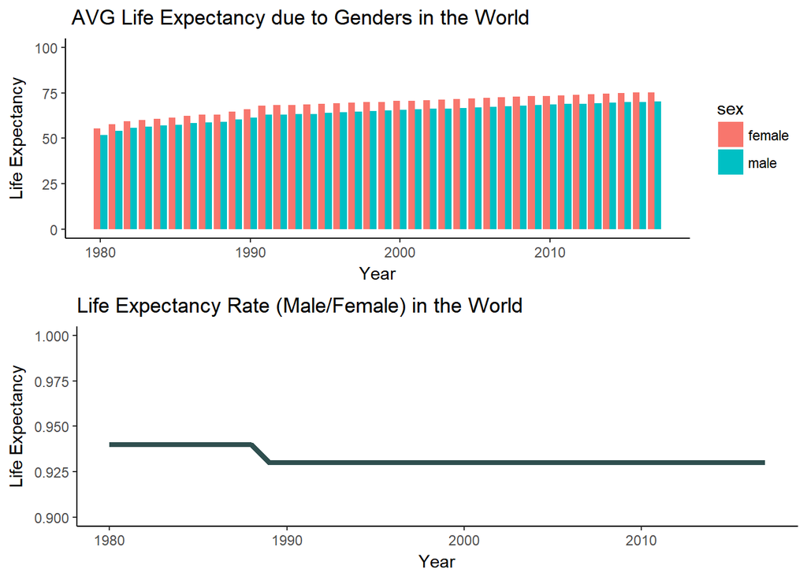

```r
 grid.arrange(g2,g3,ncol=1)
```

- As it is shown on belove graphs; average of life expectancy of females in Turkey and all around the world, always higher than males from 1980 till now. However, after 1990; male/female ratio of life expectancy has decreased in the World.